# CITS4009 Project 2 — Modelling

2023-10-17

## Introduction

The data provided in the “data.csv” file appears to be related to popular YouTube channels. It includes information such as the channel name, number of subscribers, video views, category, and various statistics related to these channels. This data can be used for analysis, insights, and comparisons of different YouTube channels’ performance.

```r
library(ggplot2)
library(gridExtra)
library(dplyr)
library(ggthemes)
library(numform)
library(timeDate)
library(lubridate)
library(reshape2)
library(ca)
library(tidyr)
library(ape)
library(knitr)
library(ROCR)
library(rpart)
library(grid)
library(gridExtra)
library(tidyverse)
library(data.table)
library(xgboost)
library(vtreat)
```

Setting up a plotting theme so that all charts look coherent

```r
cits4009_theme <- theme_few() + # Theme based on S. Few's "Practical Rules for Using Color in Charts"
                  theme(plot.title = element_text(color = "darkred")) +
                  theme(strip.text.x = element_text(size = 14, colour = "#202020")) +
                  theme(plot.margin=margin(10,30,10,30))

cits4009_map_theme <- cits4009_theme +
                      theme(panel.grid = element_blank(),
                            panel.border = element_blank(),
                            legend.position="top", legend.direction = 'horizontal',
                            axis.title.x=element_blank(),
                            axis.text.x=element_blank(),
                            axis.ticks.x=element_blank(),
                            axis.title.y=element_blank(),
                            axis.text.y=element_blank(),
                            axis.ticks.y=element_blank())

cits4009_radar_theme <- theme(plot.title = element_text(color = "darkred", size = 14, hjust = 0.5)) +
                  theme(strip.text.x = element_text(size = 12, colour = "#202020")) +
                  theme(plot.margin=margin(1,1,1,1))
```

```r
data <- read.csv('data.csv')
head(data)
```

```
##   rank                   Youtuber subscribers  video.views         category
## 1    1                   T-Series   245000000 228000000000            Music
## 2    2             YouTube Movies   170000000            0 Film & Animation
## 3    3                    MrBeast   166000000  28368841870    Entertainment
## 4    4 Cocomelon - Nursery Rhymes   162000000 164000000000        Education
## 5    5                  SET India   159000000 148000000000            Shows
## 6    6                      Music   119000000            0              nan
##                        Title uploads       Country Abbreviation  channel_type
## 1                   T-Series   20082         India           IN         Music
## 2              youtubemovies       1 United States           US         Games
## 3                    MrBeast     741 United States           US Entertainment
## 4 Cocomelon - Nursery Rhymes     966 United States           US     Education
## 5                  SET India  116536         India           IN Entertainment
## 6                      Music       0           nan          nan         Music
##   video_views_rank country_rank channel_type_rank
```

[output cut: 41 more lines]

## Part 1 - Classification

### Choose the response (target) variable

The chosen response variable, or dependent variable, in this analysis is “subscribers.” We’ve selected this variable because it represents a key measure of a YouTube channel’s popularity and reach. By using the number of subscribers as the response variable, we aim to understand and predict how various factors, such as video views, category, and country, influence a channel’s subscriber count. This choice allows us to explore the factors contributing to a channel’s success and popularity within the YouTube platform.

```r
# Load the required library (if not already loaded)
# install.packages("dplyr")
library(dplyr)

# Remove rows with missing values
cleaned_data <- data %>% na.omit()

# Create a dataset (replace 'your_dataset_name' with your desired dataset name)
data <- as.data.frame(cleaned_data)
data
```

```
##     rank                                            Youtuber subscribers
## 1      1                                            T-Series   245000000
## 3      3                                             MrBeast   166000000
## 4      4                          Cocomelon - Nursery Rhymes   162000000
## 5      5                                           SET India   159000000
## 9      9                                         Like Nastya   106000000
## 10    10                                       Vlad and Niki    98900000
## 11    11                                   Zee Music Company    96700000
## 12    12                                                 WWE    96000000
## 14    14                                           BLACKPINK    89800000
## 16    16                                            Sony SAB    83000000
## 18    18                                           BANGTANTV    75600000
## 20    20                                       Justin Bieber    71600000
## 21    21                                         HYBE LABELS    71300000
## 22    22                                              Zee TV    70500000
```

[output cut: 5286 more lines]

```r
# Now, you have your dataset without missing values, stored as 'your_dataset_name'.
```

```r
round(prop.table(table(data$subscribers)), 2)
```

[output not shown]

[output cut: 8 more lines]

```
##      0.00      0.00      0.00      0.00      0.00      0.01      0.00      0.00
##  41300000  41400000  41900000  42400000  42500000  43200000  43500000  44200000
##      0.00      0.00      0.00      0.00      0.00      0.00      0.00      0.00
##  44600000  44700000  45200000  45500000  46100000  46300000  46600000  47400000
##      0.00      0.00      0.00      0.00      0.00      0.00      0.00      0.00
##  47500000  47900000  48100000  52200000  52700000  52900000  53300000  53500000
##      0.00      0.00      0.00      0.00      0.00      0.00      0.00      0.00
##  54600000  56400000  56900000  57200000  57600000  58000000  58400000  59300000
##      0.00      0.00      0.00      0.00      0.00      0.00      0.00      0.00
##  59500000  64600000  65600000  65900000  68200000  70500000  71300000  71600000
##      0.00      0.00      0.00      0.00      0.00      0.00      0.00      0.00
##  75600000  83000000  89800000  96000000  96700000  98900000 106000000 159000000
##      0.00      0.00      0.00      0.00      0.00      0.00      0.00      0.00
## 162000000 166000000 245000000
##      0.00      0.00      0.00
```

### Selecting variables

Creating a selection of “subscribers” columns as predictors and the target column. We want to look at a variety of variables that could identify if any has been affected by the event. so lets look at another variable also.

```r
# Select the response variable (replace 'your_response_variable' with the actual variable name)
Y <- data$subscribers
```

```r
# Identify numerical columns (assuming you want to exclude 'character' and 'factor' columns)
numerical_columns <- data %>% select_if(is.numeric)
numerical_columns
```

```
##     rank subscribers  video.views uploads video_views_rank country_rank
## 1      1   245000000 228000000000   20082                1            1
## 3      3   166000000  28368841870     741               48            1
## 4      4   162000000 164000000000     966                2            2
## 5      5   159000000 148000000000  116536                3            2
## 9      9   106000000  90479060027     493              630            5
## 10    10    98900000  77180169894     574                8            5
## 11    11    96700000  57856289381    8548               12            3
## 12    12    96000000  77428473662   70127                7            6
## 14    14    89800000  32144597566     543               32            1
## 16    16    83000000 101000000000   71270                4            5
## 18    18    75600000  20826993957    2281              112            2
## 20    20    71600000  30608119724     249               38            1
## 21    21    71300000  28634566938    1337               46            3
## 22    22    70500000  73139054467  129204                9            6
```

[output cut: 3519 more lines]

```r
# Generate summary statistics for the entire dataset
summary(data)
```

```
##       rank         Youtuber          subscribers         video.views
##  Min.   :  1.0   Length:588         Min.   : 12300000   Min.   :2.634e+03
##  1st Qu.:212.8   Class :character   1st Qu.: 14700000   1st Qu.:4.920e+09
##  Median :453.5   Mode  :character   Median : 18600000   Median :8.770e+09
##  Mean   :470.3                      Mean   : 24284524   Mean   :1.282e+10
##  3rd Qu.:722.2                      3rd Qu.: 26400000   3rd Qu.:1.512e+10
##  Max.   :995.0                      Max.   :245000000   Max.   :2.280e+11
##    category            Title              uploads           Country
##  Length:588         Length:588         Min.   :     1.0   Length:588
##  Class :character   Class :character   1st Qu.:   434.5   Class :character
##  Mode  :character   Mode  :character   Median :  1194.5   Mode  :character
##                                        Mean   : 13968.7
##                                        3rd Qu.:  3886.5
##                                        Max.   :301308.0
##  Abbreviation       channel_type       video_views_rank   country_rank
##  Length:588         Length:588         Min.   :      1   Min.   :   1.0
##  Class :character   Class :character   1st Qu.:    224   1st Qu.:  10.0
##  Mode  :character   Mode  :character   Median :    596   Median :  44.0
##                                        Mean   : 131375   Mean   : 185.1
##                                        3rd Qu.:   1622   3rd Qu.: 107.0
##                                        Max.   :4054962   Max.   :7683.0
##  channel_type_rank video_views_for_the_last_30_days lowest_monthly_earnings
##  Min.   :   1.0    Min.   :3.000e+00                Min.   :     0
##  1st Qu.:  19.0    1st Qu.:4.867e+07                1st Qu.: 11500
##  Median :  49.0    Median :1.145e+08                Median : 28200
##  Mean   : 248.2    Mean   :2.450e+08                Mean   : 54352
##  3rd Qu.: 115.0    3rd Qu.:2.443e+08                3rd Qu.: 59025
##  Max.   :7670.0    Max.   :6.589e+09                Max.   :850900
##  highest_monthly_earnings lowest_yearly_earnings highest_yearly_earnings
##  Min.   :       0         Min.   :       0       Min.   :        0
##  1st Qu.:  183200         1st Qu.:  137400       1st Qu.:  2200000
##  Median :  451500         Median :  338650       Median :  5400000
##  Mean   :  868974         Mean   :  651725       Mean   : 10435433
##  3rd Qu.:  944300         3rd Qu.:  708225       3rd Qu.: 11300000
##  Max.   :13600000         Max.   :10200000       Max.   :163400000
##  subscribers_for_last_30_days  created_year  created_month       created_date
##  Min.   :      1              Min.   :1970   Length:588         Min.   : 1.00
##  1st Qu.: 100000              1st Qu.:2010   Class :character   1st Qu.: 8.00
##  Median : 200000              Median :2013   Mode  :character   Median :15.00
##  Mean   : 357302              Mean   :2013                      Mean   :15.21
##  3rd Qu.: 400000              3rd Qu.:2016                      3rd Qu.:22.25
##  Max.   :8000000              Max.   :2022                      Max.   :31.00
##  Gross.tertiary.education.enrollment....   Population        Unemployment.rate
##  Min.   :  7.60                          Min.   :2.025e+05   Min.   : 0.750
##  1st Qu.: 28.10                          1st Qu.:1.081e+08   1st Qu.: 5.360
##  Median : 60.00                          Median :3.282e+08   Median : 5.930
##  Mean   : 60.86                          Mean   :4.911e+08   Mean   : 8.934
##  3rd Qu.: 88.20                          3rd Qu.:3.282e+08   3rd Qu.:14.700
##  Max.   :113.10                          Max.   :1.398e+09   Max.   :14.720
##  Urban_population       Latitude        Longitude
##  Min.   :    35588   Min.   :-38.42   Min.   :-172.105
##  1st Qu.: 61300442   1st Qu.: 20.59   1st Qu.: -95.713
##  Median :270663028   Median : 30.59   Median :  -3.593
##  Mean   :239499682   Mean   : 26.20   Mean   :  -6.382
##  3rd Qu.:270663028   3rd Qu.: 37.09   3rd Qu.:  78.963
##  Max.   :842933962   Max.   : 61.52   Max.   : 138.253
```

### Checking the subscribers

```r
# Check summary statistics for the "subscribers" variable in the "data" dataset
summary(data$subscribers)
```

```
##      Min.   1st Qu.    Median      Mean   3rd Qu.      Max.
##  12300000  14700000  18600000  24284524  26400000 245000000
```

### Splitting the data

To split your dataset into training, calibration, and test sets, you can use R’s sample() function or any related functions. The specific way you split the data depends on the proportions you want for each set.

```r
# Set a random seed for reproducibility
set.seed(123)

# Define the proportions for each set (adjust as needed)
train_proportion <- 0.6   # 60% for training
calibration_proportion <- 0.2   # 20% for calibration
test_proportion <- 0.2   # 20% for testing

# Calculate the number of rows for each set
num_rows <- nrow(data)
num_train <- round(train_proportion * num_rows)
num_calibration <- round(calibration_proportion * num_rows)
num_test <- num_rows - num_train - num_calibration

# Create the indices for the sets
train_indices <- sample(1:num_rows, num_train, replace = FALSE)
remaining_data <- data[-train_indices, ]

calibration_indices <- sample(1:(num_rows - num_train), num_calibration, replace = FALSE)
test_indices <- setdiff(1:(num_rows - num_train), calibration_indices)

# Create the sets
train_set <- data[train_indices, ]
calibration_set <- remaining_data[calibration_indices, ]
test_set <- remaining_data[test_indices, ]
```

```r
# Create a list of your data sets
splits <- list(train_set, calibration_set, test_set)

# Apply the nrow function to each element in the list
lapply(splits, nrow)
```

```
## [[1]]
## [1] 353
##
## [[2]]
## [1] 118
##
## [[3]]
## [1] 117
```

```r
# This will give you a list of row counts for each data set
```

To split your data into categorical and numerical variables, you can loop through the columns in your dataset and check their data types.

```r
# Assuming 'data' is your dataset

# Initialize empty lists for categorical and numerical variables
categorical_vars <- character(0)
numerical_vars <- character(0)

# Loop through columns
for (col in names(data)) {
  if (is.factor(data[[col]]) || is.character(data[[col]])) {
    # If the column is a factor or character, consider it categorical
    categorical_vars <- c(categorical_vars, col)
  } else if (is.numeric(data[[col]])) {
    # If the column is numeric, consider it numerical
    numerical_vars <- c(numerical_vars, col)
  }
}

# Now, 'categorical_vars' and 'numerical_vars' contain the names of categorical and numerical variables, respectively.
```

```r
 numerical_vars
```

```
##  [1] "rank"
##  [2] "subscribers"
##  [3] "video.views"
##  [4] "uploads"
##  [5] "video_views_rank"
##  [6] "country_rank"
##  [7] "channel_type_rank"
##  [8] "video_views_for_the_last_30_days"
##  [9] "lowest_monthly_earnings"
## [10] "highest_monthly_earnings"
## [11] "lowest_yearly_earnings"
## [12] "highest_yearly_earnings"
## [13] "subscribers_for_last_30_days"
## [14] "created_year"
## [15] "created_date"
## [16] "Gross.tertiary.education.enrollment...."
## [17] "Population"
## [18] "Unemployment.rate"
## [19] "Urban_population"
## [20] "Latitude"
## [21] "Longitude"
```

```r
categorical_vars
```

```
## [1] "Youtuber"      "category"      "Title"         "Country"
## [5] "Abbreviation"  "channel_type"  "created_month"
```

Here is a function that is used for Single variable predictions for categorical variables.

```r
# Function for single variable predictions for categorical variables
target_var = Y
single_variable_predictions <- function(data, categorical_var, target_var) {
  # Check if the specified variables exist in the dataset
  if (!(categorical_var %in% names(data)) || !(target_var %in% names(data))) {
    stop("Specified variables not found in the dataset.")
  }

  # Create a summary table of target variable values based on categorical variable
  summary_table <- table(data[[categorical_var]], data[[target_var]])

  return(summary_table)
}
Y = target_var
```

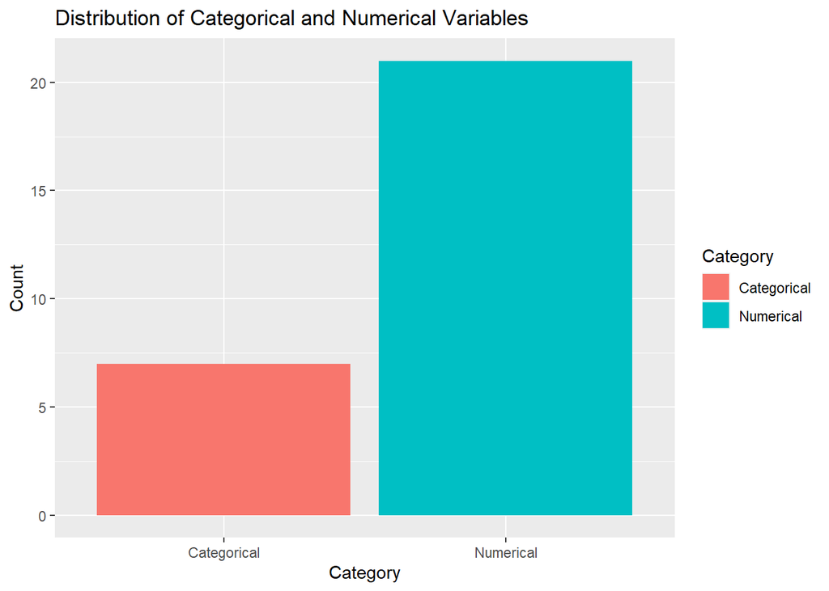

```r
# Assuming you have already split your data into categorical and numerical variables

# Load the ggplot2 library
# install.packages("ggplot2")
library(ggplot2)

# Create a data frame for visualization
variable_counts <- data.frame(
  Category = c("Categorical", "Numerical"),
  Count = c(length(categorical_vars), length(numerical_vars))
)

# Create a bar plot
ggplot(variable_counts, aes(x = Category, y = Count, fill = Category)) +
  geom_bar(stat = "identity") +
  labs(title = "Distribution of Categorical and Numerical Variables")
```

```r
# Alternatively, create a pie chart
# ggplot(variable_counts, aes(x = "", y = Count, fill = Category)) +
#   geom_bar(stat = "identity", width = 1) +
#   coord_polar(theta = "y") +
#   labs(title = "Distribution of Categorical and Numerical Variables")
```

### Evaluation of Models

```r
evaluate_models <- function(models, train_set, test_set) {
  # Initialize lists to store results for each model
  roc_curves <- list()
  prediction_distributions <- list()
  precision_recall_curves <- list()
  confusion_matrices <- list()
  null_model_log_likelihoods <- numeric(length(models))

  # Loop through each model
  for (i in 1:length(models)) {
    # Fit the model on the training set
    fitted_model <- fit_model(models[[i]], train_set)

    # Make predictions on the test set
    predictions <- predict(fitted_model, test_set)

    # Calculate ROC curve
    roc <- calculate_roc(predictions, test_set$actual_outcomes)
    roc_curves[[i]] <- roc

    # Calculate prediction distribution plot
    prediction_dist <- plot_prediction_distribution(predictions)
    prediction_distributions[[i]] <- prediction_dist

    # Calculate precision/recall curve
    precision_recall <- calculate_precision_recall(predictions, test_set$actual_outcomes)
    precision_recall_curves[[i]] <- precision_recall

    # Calculate confusion matrix
    confusion_matrix <- create_confusion_matrix(predictions, test_set$actual_outcomes)
    confusion_matrices[[i]] <- confusion_matrix

    # Calculate null model log likelihood
    null_model_log_likelihood <- calculate_null_model_log_likelihood(test_set$actual_outcomes)
    null_model_log_likelihoods[i] <- null_model_log_likelihood
  }

  # Return the results for all models
  return(list(
    roc_curves = roc_curves,
    prediction_distributions = prediction_distributions,
    precision_recall_curves = precision_recall_curves,
    confusion_matrices = confusion_matrices,
    null_model_log_likelihoods = null_model_log_likelihoods
  ))
}
```

## Multivariate models

```r
# Load necessary libraries
library(caret)
# Create a binary target variable for classification based on 'subscribers'
data$high_subscribers <- ifelse(data$subscribers > 100000, "High", "Low")

# Split the data into training and test sets
set.seed(123)  # For reproducibility
train_index <- createDataPartition(data$high_subscribers, p = 0.8, list = FALSE)
train_data <- data[train_index, ]
test_data <- data[-train_index, ]
```

```r
train_data
```

```
##     rank                                            Youtuber subscribers
## 4      4                          Cocomelon - Nursery Rhymes   162000000
## 5      5                                           SET India   159000000
## 9      9                                         Like Nastya   106000000
## 10    10                                       Vlad and Niki    98900000
## 11    11                                   Zee Music Company    96700000
## 12    12                                                 WWE    96000000
## 16    16                                            Sony SAB    83000000
## 18    18                                           BANGTANTV    75600000
## 20    20                                       Justin Bieber    71600000
## 21    21                                         HYBE LABELS    71300000
## 22    22                                              Zee TV    70500000
## 25    25               ChuChu TV Nursery Rhymes & Kids Songs    65900000
## 29    29                                        Dude Perfect    59500000
## 30    30                                          Movieclips    59500000
```

[output cut: 4705 more lines]

```r
data$Y <- as.factor(data$Y)

# Decision tree with party
library(party)
```

[figure not shown]

```r
mytree <- ctree(Y~ video.views + uploads +lowest_monthly_earnings+video_views_for_the_last_30_days+video_views_rank+country_rank ,data, controls=ctree_control(mincriterion=0.9, minsplit=50))
plot(mytree,type="simple")
```

```r
# Misclassification error
tab <- table(predict(mytree), data$Y)
1-sum(diag(tab))/sum(tab)
```

```
## [1] 0.9982993
```

### logistic regression model

```r
# Load necessary libraries
data=read.csv('data.csv')
Y=data$subscribers
library(caret)
library(glm2)

# Prepare your data
data$target <- ifelse(data$Y > 1000000, 1, 0)  # Define a binary target variable based on some threshold
# Check for missing values in the 'target' and 'subscribers' columns
any(is.na(data$target))
```

```
## [1] FALSE
```

```r
any(is.na(data$subscribers))
```

```
## [1] FALSE
```

```r
# If there are missing values, you may need to handle them.
# For example, you can remove rows with missing values:
data <- na.omit(data)

# Now, split the data into training and test sets
set.seed(123)  # For reproducibility
train_index <- createDataPartition(data$target, p = 0.8, list = FALSE)
train_data <- data[train_index, ]
test_data <- data[-train_index, ]

# Ensure consistent levels for the target variable in both datasets
train_data$target <- factor(train_data$target, levels = c(0, 1))
test_data$target <- factor(test_data$target, levels = c(0, 1))

# Train a logistic regression model
logistic_model <- train(target ~ subscribers, data = train_data, method = "glm", family = "binomial")
print(logistic_model)
```

```
## Generalized Linear Model
##
## 471 samples
##   1 predictor
##   2 classes: '0', '1'
##
## No pre-processing
## Resampling: Bootstrapped (25 reps)
## Summary of sample sizes: 471, 471, 471, 471, 471, 471, ...
## Resampling results:
##
##   Accuracy   Kappa
##   0.8765146  -0.001561113
```

```r
# Interpret and explain the logistic regression model
# Analyze the impact of "subscribers" on the binary target
```

### k means clustering

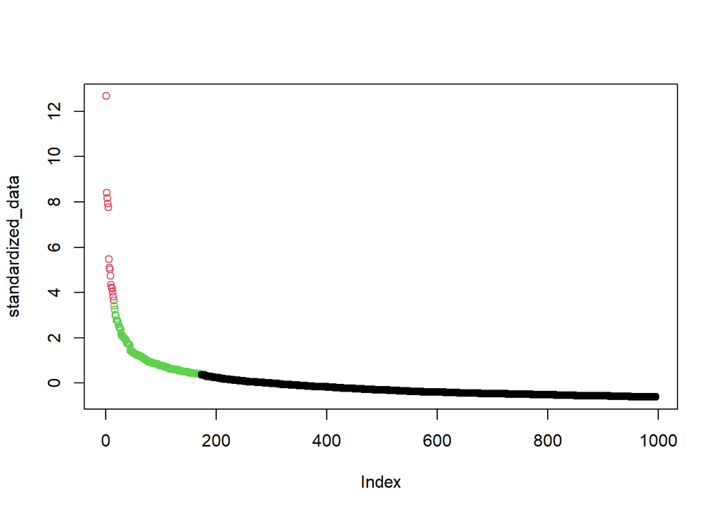

```r
# Load necessary libraries
library(stats)
data=read.csv('data.csv')

# Standardize or normalize your feature variables
standardized_data <- scale(data$subscribers)

# Determine the number of clusters (k)
# Use the Elbow Method, Silhouette Score, or other techniques to find the optimal k

# Apply k-means clustering
k <- 3  # Replace with your chosen k value
cluster_model <- kmeans(standardized_data, centers = k)

# Visualize the clustering results
plot(standardized_data, col = cluster_model$cluster)
```

```r
# Interpret and explain the clusters
# Analyze cluster characteristics and patterns
```